# 통계 방법론Ⅱ - 탐색적 데이터 분석

응용통계학과 이준혁

2023-06-10(토)

# Ch10. 평활화(Smoothing)

- 2개의 연속형 변수(x, y)의 경우에는 그 관계와 밀접도에 대한 정보를 얻기 위하여 **산점도(Scatter Plots)**를 이용한다.
- x 변수가 동일(또는 거의 일정한) 간격을 갖는 값으로 순서(order)에 따라 주어지는 경우(나이, 회수, 위/경도 등)에는 x의 각 지점에 따라 y의 변화 패턴을 확인하는 **평활화(smoothing)**을 해볼 수 있다.
  - 엄마의 연령대별로 정의된 출산률(birth-rates)
  - 환자의 몸무게에 따른 심근 경색의 발생 빈도
  - 분기별 제품 판매액
- **stats::smooth()**: Tukey의 다양한 평활화 방법을 제공

## 10.0. info

- 고객 데이터가 들어오면 평활화를 계속한 다음, 잔차를 해석해보는 것이 중요하다.
  - 현 시대에서는 평활화를 통해서 패턴을 파악하면 가구원수를 파악 하는 것이 가능하다.
- 패턴과 패턴을 비교해보면 의미있는 결과를 얻을 수가 있어서 좋은 방법이다.
- 평활화 자체가 분석의 목적일수도 있고 평활 후의 잔차가 목표일수도 있다.
- EDA라는 것은 새로운 가설을 찾아가는 과정이다.
- 최대한 스무스한 패턴을 찾고 거침(잔차)를 해석하는 것이 핵심이다.
  - 상승과 하강 지점에 대한 해석!
- Data set ⊃ Data Sequence ⊃ Time Series
  - Data = 주요약(fit) + 잔차(residuals) = 평활화(smooth) + 거침(rough)
  - Data Sequence: x의 순서에 따라 기록된 y의 값만으로 나타낸 구조
    - 만일 x가 연속적인 시간(time) 간격이라면, y의 데이터 시퀀스(data sequence)를 **시계열(time series)**라고 부름
    - $y_t,t=1,2,3,4,...,n$, 일반적으로 x 대신에 순서로 정의되는 값 t로 표시
      - 데이터 시퀀스에 대한 첫번째 시도는 부드러운 곡선을 적합
        - 이를 통해 크게 변하는 지점을 구별하여 어떤 규칙과 주기가 있는 지 검토한다.
        - 이렇게 추정된 곡선을 평활(smooth), 이를 벗어나는 데이터들의 잔차를 거침(rough)
    - 데이터 평활기(data smoothers): 데이터 시퀀스의 중복된 구획(segments)에서 평활(smooth)을 달성하고자 중앙값 또는 평균을 이용
      - 이를 통하여 도출된 평활을 제외한 나머지 잔차가 거침(rough)을 결정한다.
- **EDA에서는 평활의 수학적 공식보다 거침의 패턴해석을 더 중요시한다.**

## 10.1. 중앙값 평활기 Median Smoothers

- 중앙값 평활기는 주어진 데이터 시퀀스에 대하여 고정된 일정 개수 k≥3의 연속적으로(running) 분할된 구획(segments)별 중앙값을 이용하여 데이터 시퀀스를 평활화하는 것이다.
  - k-연속 중앙값 평활기라고 부름
- 평활 대상이 되는 데이터 시퀀스의 첫번째($y_1$)과 마지막($y_n$)을 데이터 시퀀스의 끝점(End Points)라 한다.
- 3R: 평활된 값이 변화가 없을 때까지 반복적으로 평활하는 방법을 의미한다.
- Tukey’s End Point Rule
  - 평활값을 구할 수 없는 경우가 발생할 때 적용
  - 평활화의 끝점(End Points of Smoothing; EPS)은 다음의 범칙에 의해 결정
    - EPS값에서 EPS 하나 이전의 값의 변화는 EPS 하나 이전의 값에서 EPS 두개 이전의 값으로의 변화의 0~2배 사이
    - EPS 값은 가능한 한 데이터 시퀀스의 값과 비슷하게 결정

## 10.2. 분리, 재평활 그리고 해닝 Spliting, Rerough and Hanning

- 이 챕터부터는 평활화를 돕는 기법이라고 생각하고 이해하면 된다.
- 중복 평활을 적용할수록 보다 부드러운 형태로 평활된다.
- **분리 평활(Split Smoothing)**: 중앙값 평활기를 적용한 이후 생성된 피크(peak)와 밸리(valley)를 각각 2개로 분리하여 끝점들을 평활한 후 중앙값 평활기를 재적용하여 평활된 결과를 향상시키는 방법
  - 중앙값 평활기의 적용
  - 동일한 값으로 평활된 피크 또는 밸리를 기준으로 2개의 데이터 시퀀스를 결정
  - 각각에 대하여 Tukey’s End Point Rule 적용
  - 통합하여 중앙값 평활기 적용 -> 이 과정을 **3RSS**라고 함
- **재평활(Rerough)**: 거침(rough)에 남아 있는 패턴을 추가로 설명하기 위하여 다음의 절차를 적용
  - 이러한 방법을 **3RS3R, Twice**라고 부름
    - data = smooth + rough
    - rough = smooth(rough) + rough(rough)
    - data = [smooth + smooth(rough)] + rough(rough) = final.smooth + final.rough
- **해닝(Hanning)**: 데이터 시퀀스에서 인접한 3개의 값들에 대한 가중 평균(weighted mean)을 이용한 평활 방법
  - $h_1=y_1$
  - $h_i=1/4y_{i-1}+1/2y_i+1/4y_{i+1},i>1$

## 10.3. 2022년 K리그(Kleague.csv) 분석

- 2022년 K리그 데이터셋은 한국 축구의 날짜별로 원정팀/홈팀에 따른 관중 수를 정리한 데이터셋이다. 해당 데이터셋을 통해서 날씨, 온도, 경기 지역과 같은 변수도 알 수 있다.

|  | Variable | Description | 변수 구분 |
| --- | --- | --- | --- |
| 1 | gday | 경기 날짜 | 날짜 변수 |
| 2 | game | 경기 순번 | 이산형 |
| 3 | league | 1군, 2군 구분 | 명목형 |
| 4 | month | 달 | 명목형 |
| 5 | day | 일 | 명목형 |
| 6 | date | 요일 | 명목형 |
| 7 | home | 홈팀 | 명목형 |
| 8 | visitor | 원정팀 | 명목형 |
| 9 | arena | 경기장 | 명목형 |
| 10 | weather | 날씨 | 명목형 |
| 11 | temp | 온도 | 연속형 |
| 12 | spectator | 관중 수 | 연속형 |

### 10.3.1. 데이터 불러오기

```r
league <- read.csv(paste0(data_path, "kleague.2022.csv"), header = TRUE)
```

### 10.3.2. 데이터의 구조 확인

변수와 케이스의 수 그리고 변수의 유형을 확인하고, 결측값(missing value; NA)의 존재여부를 확인한다.

```r
head(league)
```

```
##    gday game     league month day date      home  visitor              arena
## 1 03-01    1 K LEAGUE 1     3   1   화 수원 삼성 제주 Utd   수원월드컵경기장
## 2 03-01    2 K LEAGUE 1     3   1   화   성남 FC  FC 서울     탄천종합운동장
## 3 03-01    3 K LEAGUE 1     3   1   화   강원 FC 인천 Utd     강릉종합운동장
## 4 03-01    4 K LEAGUE 1     3   1   화 울산 현대  수원 FC 울산문수축구경기장
## 5 03-01    5 K LEAGUE 1     3   1   월   성남 FC 제주 Utd     탄천종합운동장
## 6 03-01    6 K LEAGUE 1     3   1   월 울산 현대  강원 FC 울산문수축구경기장
##   weather temp spectator
## 1      비  8.8      4022
## 2      비  8.8      2393
## 3      비  8.2      1559
## 4      비 16.9      5260
## 5      눈  8.1      1218
## 6      비 16.0      3943
```

- 1161 obs. of 12 variables의 데이터프레임을 보인다.

```r
str(league)
```

```
## 'data.frame':    1161 obs. of  12 variables:
##  $ gday     : chr  "03-01" "03-01" "03-01" "03-01" ...
##  $ game     : int  1 2 3 4 5 6 7 8 9 10 ...
##  $ league   : chr  "K LEAGUE 1" "K LEAGUE 1" "K LEAGUE 1" "K LEAGUE 1" ...
##  $ month    : int  3 3 3 3 3 3 5 5 5 5 ...
##  $ day      : int  1 1 1 1 1 1 1 1 1 1 ...
##  $ date     : chr  "화" "화" "화" "화" ...
##  $ home     : chr  "수원 삼성" "성남 FC" "강원 FC" "울산 현대" ...
##  $ visitor  : chr  "제주 Utd" "FC 서울" "인천 Utd" "수원 FC" ...
##  $ arena    : chr  "수원월드컵경기장" "탄천종합운동장" "강릉종합운동장" "울산문수축구경기장" ...
##  $ weather  : chr  "비" "비" "비" "비" ...
##  $ temp     : num  8.8 8.8 8.2 16.9 8.1 16 15.2 14.2 14.2 13.3 ...
##  $ spectator: int  4022 2393 1559 5260 1218 3943 2650 3045 570 1323 ...
```

- 온도 데이터만 28개의 결측치가 존재한다.

```r
na_count(league)
```

```
##      gday      game    league     month       day      date      home   visitor
##         0         0         0         0         0         0         0         0
##     arena   weather      temp spectator
##         0         0        28         0
```

### 10.3.3. K리그 1의 팀들 간의 평균 관중 수 확인

- **stats::aggregate():**: 데이터를 구분하여 요약값을 구하고 이를 반환
  - aggregate(formula, data, FUN)
    - FUN : 각 그룹에 대해 적용할 함수로 요약 통계를 계산하는데 사용되는 함수(mean, sum, max)가 쓰인다.

```r
vr <- aggregate(spectator~ home + visitor,
                data = subset(league, league == "K LEAGUE 1"),
                mean
                )
vr
```

```
##              home       visitor spectator
## 1         강원 FC       FC 서울 1349.5000
## 2         광주 FC       FC 서울  765.3333
## 3        김천상무       FC 서울 1794.5000
## 4         대구 FC       FC 서울 4661.0000
## 5   부산 아이파크       FC 서울    0.0000
## 6       상주 상무       FC 서울    0.0000
## 7         성남 FC       FC 서울 1249.6000
## 8         수원 FC       FC 서울 4037.0000
## 9       수원 삼성       FC 서울 4508.5000
## 10      울산 현대       FC 서울 3293.0000
## 11       인천 Utd       FC 서울 3700.4000
## 12      전북 현대       FC 서울 5485.2000
## 13       제주 Utd       FC 서울 1984.3333
## 14  포항 스틸러스       FC 서울 3613.2000
```

[output cut: 182 more lines]

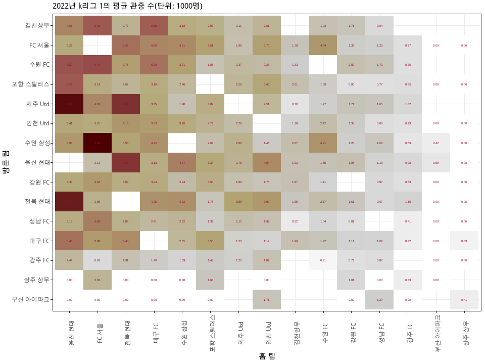

```r
vr %>%
  ggplot(aes(fct_reorder(home, -spectator),
             fct_reorder(visitor, spectator),
             fill = spectator
             )
         ) +
  geom_tile() +
  geom_text(aes(label = sprintf("%0.2f", round(spectator/1000, 2))),
            color = lre,
            size = 1.5
            ) +
  labs(x = "홈 팀",
       y = "방문 팀",
       subtitle = "2022년 k리그 1의 평균 관중 수(단위: 1000명)"
       ) +
  theme_bw() +
  theme(axis.text.x = element_text(angle = 90), legend.position = "none") +
  scico::scale_fill_scico("lajolla")
```

### 10.3.4. 데이터 선별: 울산 현대

- 리그 중에 특정 일에 2개 이상의 경기가 진행되므로 특정 팀의 경기를 선택한다.
  - 이때 관중이 없는 게임은 제거한다.
  - 경기 간의 일자 간격은 동일하지 않다.
    - 일자 간격이 동일하지 않아도 이정도는 감소하고 진행한다.

```r
ulsan <- league %>%
  dplyr::filter(spectator != 0) %>%
  dplyr::filter(home == "울산 현대" | visitor == "울산 현대") %>%
  dplyr::arrange(gday) %>%
  mutate(ugame = seq(1, length(gday), 1))
```

### 10.3.5. 평활화 방법 적용

- **stats::smooth()**는 Tukey의 k-연속 중앙값 평활기의 다양한 옵션을 제공한다.
  - **smooth(x, kind = c(“3RS3R”, “3RSS”, “3RSR”, “3R”, “3”, “S”), twiceit = FALSE)**
    - 3: 3-중앙값 평활기 1회 적용
    - 3R: 3-중앙값 평활기(수렴할 때까지) 반복 적용
    - S: 분리 평활 적용
    - 3RSS: 3R + S 적용
    - 3RS3R: 3R + S + 3R 동시 적용
    - twiceit = TRUE: 재평활 적용
- **LearnEDAfunctions::han(sequnce)**: 해닝 적합을 제공

```r
#평활화(smooth) 구하기
ulsan$s.3R <- smooth(ulsan$spectator, kind = "3R")
ulsan$s.3RSS <- smooth(ulsan$spectator, kind = "3RSS")
ulsan$s.3RS3R2 <- smooth(ulsan$spectator, kind = "3RS3R", twiceit = TRUE)
ulsan$s.3RS3R2H <- han(smooth(ulsan$spectator, kind = "3RS3R", twiceit = TRUE))
```

```r
#거침(rough) 구하기
ulsan$rough.3R <- ulsan$spectator - ulsan$s.3R
ulsan$rough.3RSS <- ulsan$spectator - ulsan$s.3RSS
ulsan$rough.3RS3R2 <- ulsan$spectator - ulsan$s.3RS3R2
ulsan$rough.3RS3R2H <- ulsan$spectator - ulsan$s.3RS3R2H
```

### 10.3.6. 평활화 결과 확인

- 가장 기본적인 3R 평활부터 3RS3R에 해닝(Hanning)기법까지 적용하여 결과를 살펴 보았다.
- 최종단계에서는 초기 단계보다 훨씬 스무스한 패턴을 가지는 것을 알 수 있었다.
- 3R 평활(smooth)

```
## Defaulting to continuous.
```

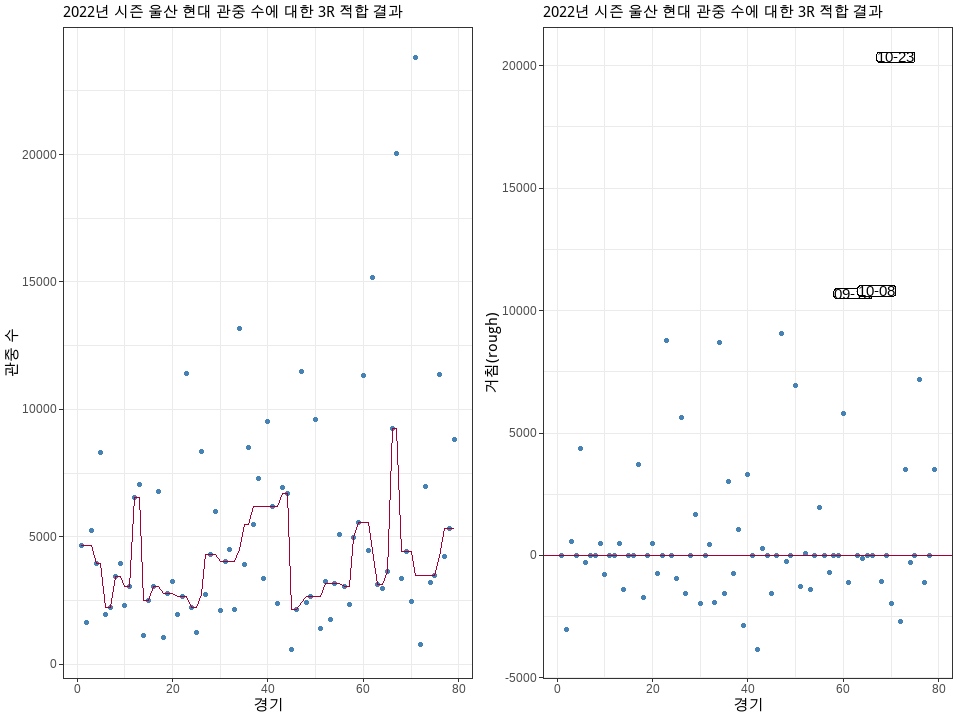

```r
g1 <- ulsan %>%
  ggplot(aes(ugame, spectator)) +
  geom_point(color = sbl) +
  geom_line(aes(ugame, s.3R), color = lre) +
  labs(x = "경기",
       y = "관중 수",
       subtitle = "2022년 시즌 울산 현대 관중 수에 대한 3R 적합 결과") +
  theme_bw()
g2 <- ulsan %>%
  ggplot(aes(ugame, rough.3R)) +
  geom_point(color = sbl) +
  geom_hline(yintercept = 0, color = lre) +
  geom_label(data = ulsan %>%
               filter(rough.3R >= 10000), aes(ugame, rough.3R, label = gday),
               label.padding = unit(0.01, "lines")) +
  labs(x = "경기",
       y = "거침(rough)",
       subtitle = "2022년 시즌 울산 현대 관중 수에 대한 3R 적합 결과") +
  theme_bw()

grid.arrange(g1, g2, ncol = 2)
```

- 3RSS 평활(smooth)

```
## Defaulting to continuous.
```

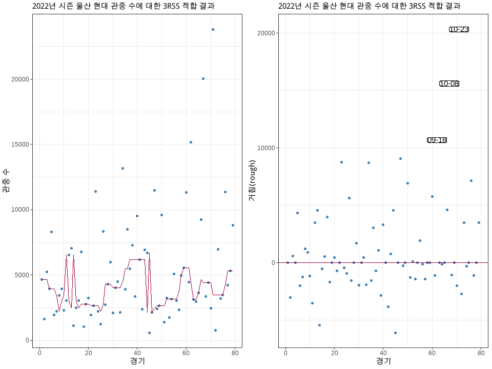

```r
g1 <- ulsan %>%
  ggplot(aes(ugame, spectator)) +
  geom_point(color = sbl) +
  geom_line(aes(ugame, s.3RSS), color = lre) +
  labs(x = "경기",
       y = "관중 수",
       subtitle = "2022년 시즌 울산 현대 관중 수에 대한 3RSS 적합 결과") +
  theme_bw()
g2 <- ulsan %>%
  ggplot(aes(ugame, rough.3RSS)) +
  geom_point(color = sbl) +
  geom_hline(yintercept = 0, color = lre) +
  geom_label(data = ulsan %>%
               filter(rough.3RSS >= 10000), aes(ugame, rough.3RSS, label = gday),
               label.padding = unit(0.01, "lines")) +
  labs(x = "경기",
       y = "거침(rough)",
       subtitle = "2022년 시즌 울산 현대 관중 수에 대한 3RSS 적합 결과") +
  theme_bw()

grid.arrange(g1, g2, ncol = 2)
```

- 3RS3R2 평활(smooth)

```
## Defaulting to continuous.
```

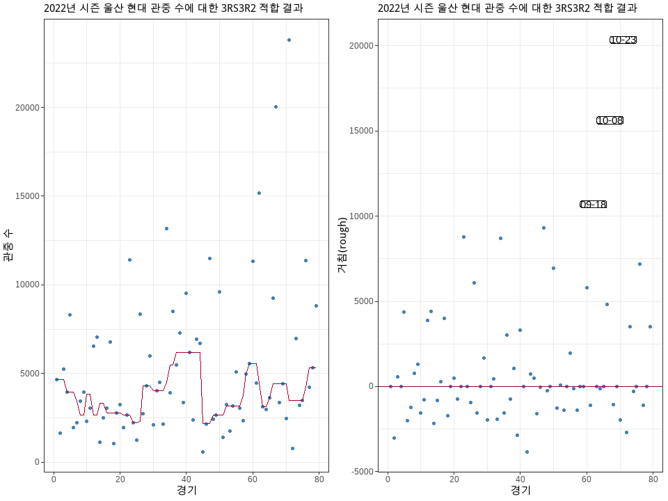

```r
g1 <- ulsan %>%
  ggplot(aes(ugame, spectator)) +
  geom_point(color = sbl) +
  geom_line(aes(ugame, s.3RS3R2), color = lre) +
  labs(x = "경기",
       y = "관중 수",
       subtitle = "2022년 시즌 울산 현대 관중 수에 대한 3RS3R2 적합 결과") +
  theme_bw()
g2 <- ulsan %>%
  ggplot(aes(ugame, rough.3RS3R2)) +
  geom_point(color = sbl) +
  geom_hline(yintercept = 0, color = lre) +
  geom_label(data = ulsan %>%
               filter(rough.3RS3R2 >= 10000), aes(ugame, rough.3RS3R2, label = gday),
               label.padding = unit(0.01, "lines")) +
  labs(x = "경기",
       y = "거침(rough)",
       subtitle = "2022년 시즌 울산 현대 관중 수에 대한 3RS3R2 적합 결과") +
  theme_bw()

grid.arrange(g1, g2, ncol = 2)
```

- 3RS3RH 평활(smooth)

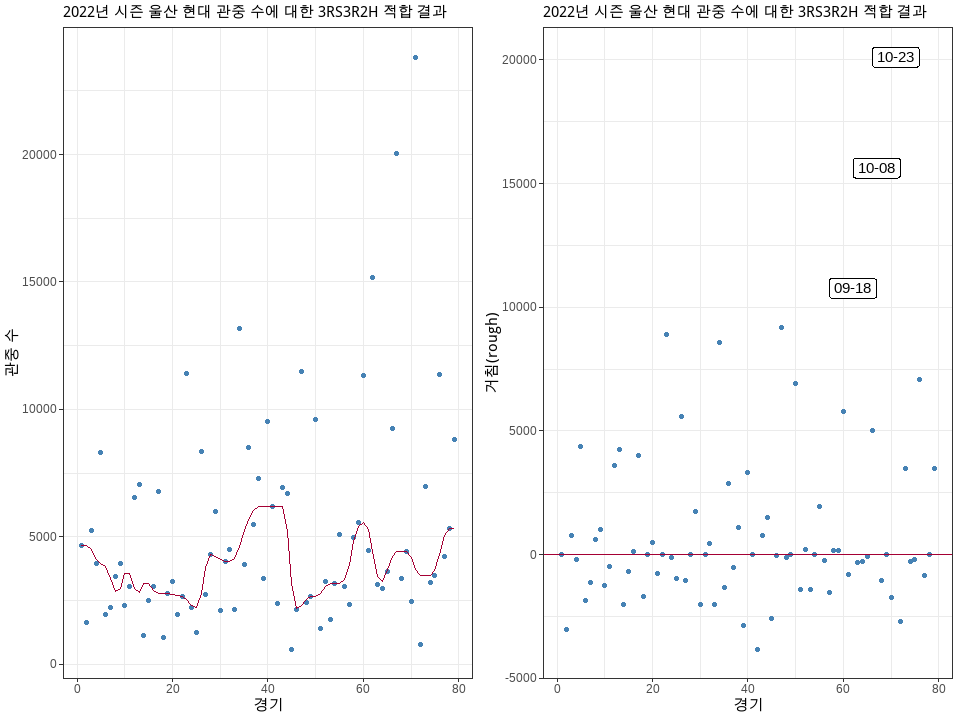

```r
g1 <- ulsan %>%
  ggplot(aes(ugame, spectator)) +
  geom_point(color = sbl) +
  geom_line(aes(ugame, s.3RS3R2H), color = lre) +
  labs(x = "경기",
       y = "관중 수",
       subtitle = "2022년 시즌 울산 현대 관중 수에 대한 3RS3R2H 적합 결과") +
  theme_bw()
g2 <- ulsan %>%
  ggplot(aes(ugame, rough.3RS3R2H)) +
  geom_point(color = sbl) +
  geom_hline(yintercept = 0, color = lre) +
  geom_label(data = ulsan %>%
               filter(rough.3RS3R2H >= 10000), aes(ugame, rough.3RS3R2H, label = gday)) +
  labs(x = "경기",
       y = "거침(rough)",
       subtitle = "2022년 시즌 울산 현대 관중 수에 대한 3RS3R2H 적합 결과") +
  theme_bw()

grid.arrange(g1, g2, ncol = 2)
```

- 관중 수가 평활 패턴보다 만명이상 많았던 날은 9월 18일, 10월 8일, 10월 23일로 확인되었다. - 해당 경기의 실제 경기 일정을 찾아보면 주말경기이면서 리그 순위가 중요한 날로 확인할 수 있다. - K리그의 흥행을 불러오면서 관객을 더 모으기 위해서 가능하면 울산 현대, 전북 현대 모터스, FC서울같이 팬층이 두텁고 인기 있는 팀의 경기를 리그 후반부 주말에 배치하면 될 것이다.

### 10.3.7. 전북 현대 평활화 적용

- 울산 현대말고 유명한 구단인 전북 현대 관중 수에 평활화 기법을 적용해보았다.
- 전북 현대로 선정한 이유는 다음과 같다.
  - 팬층이 두터움
  - K리그에서 최다 우승한 구단
  - 강등을 한번도 당하지 않은 구단
- 울산 현대에 적용했던 것과 마찬가지로 다음과 같은 규칙을 적용했다.
  - 리그 중에 특정 일에 2개 이상의 경기가 진행되므로 특정 팀의 경기를 선택한다.
    - 이때 관중이 없는 게임은 제거한다.
    - 경기 간의 일자 간격은 동일하지 않다.
      - 일자 간격이 동일하지 않아도 이정도는 감소하고 진행한다.

```r
JB <- league %>%
  dplyr::filter(spectator != 0) %>%
  dplyr::filter(home == "전북 현대" | visitor == "전북 현대") %>%
  dplyr::arrange(gday) %>%
  mutate(jgame = seq(1, length(gday), 1))
```

```r
#평활화 구하기
JB$s.3RS3R2H <- han(smooth(JB$spectator, kind = "3RS3R", twiceit = TRUE))
```

```r
#거침 구하기
JB$rough.3RS3R2H <- JB$spectator - JB$s.3RS3R2H
```

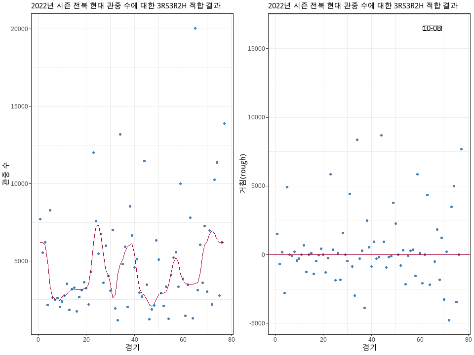

```r
#전북 현대 3RS3R2H 평활(smooth)
g1 <- JB %>%
  ggplot(aes(jgame, spectator)) +
  geom_point(color = sbl) +
  geom_line(aes(jgame, s.3RS3R2H), color = lre) +
  labs(x = "경기",
       y = "관중 수",
       subtitle = "2022년 시즌 전북 현대 관중 수에 대한 3RS3R2H 적합 결과") +
  theme_bw()
g2 <- JB %>%
  ggplot(aes(jgame, rough.3RS3R2H)) +
  geom_point(color = sbl) +
  geom_hline(yintercept = 0, color = lre) +
  geom_label(data = JB %>%
               filter(rough.3RS3R2H >= 10000), aes(jgame, rough.3RS3R2H, label = gday),
               label.padding = unit(0.01, "lines")) +
  labs(x = "경기",
       y = "거침(rough)",
       subtitle = "2022년 시즌 전북 현대 관중 수에 대한 3RS3R2H 적합 결과") +
  theme_bw()

grid.arrange(g1, g2, ncol = 2)
```

- 관중 수가 평활 패턴보다 유독 많았던 날은 10월 8일이다.
- 10월 8일은 이전에 분석해보았던 울산 현대와 겹치는 날인데 거의 매년 리그 1, 2를 다투는 두 구단이 만났을 가능성이 높은 날이다.
- 실제로 찾아본 결과, 두 구단이 10월 8일에 경기를 해서 울산이 승리하여 울산이 우승 확정을 만들어 가는 날임을 알 수 있었다.
- 이렇게 평활화를 적용해 보았는데 관중 수가 많은 날들을 조사하여 마케팅에 활용하면 더욱더 관중수를 모을 수 있을 것으로 판단된다.
  - 이러한 점은 K리그뿐만 아니라 다른 스포츠도 적용해보면 스포츠 관객수를 모으는데 큰 도움이 될 것이다.
- E-Sport 중 하나인 LCK(리그오브레전드 코리아)에서는 실제로 라이벌 구도인 팀들, 팬층이 두터운 팀 경기를 가장 많은 시청자를 모을 수 있는 주말에 배치하여 효과를 보고 있는 것으로 알려져 있다.
  - 이번년도에 첫 시행이 된 사항이므로 향후 정규 리그가 끝난 이후에 지난 리그들과 비교하여 시청자수가 얼마나 변화했는지 알아 볼 예정이다.